# Tugas Praktikum 2 MPDW

G1401231072 - Aurisa Putri Hawin Yusima

2025-08-31

## Library/Packages

```r
#install.packages("forecast")
#install.packages("graphics")
#install.packages("TTR")
#install.packages("TSA")
```

Jika sudah ada, silakan panggil library *package* tersebut.

```r
library("forecast")
```

```r
library("graphics")
library("TTR")
library("TSA")
```

## Impor Data

```r
library(rio) #install packages jika belum ada
dataco <- import("E:\\Kuliah\\MPDW\\Crude Oil Price Data 1-127.xlsx")

#via csv gunakan read.csv("namafile.csv")
#data1 <- read.csv("Data_1.csv")

# menampilkan 5 data pertama
head(dataco)
```

```
##   Period Price PercentChange Change
## 1      1 29.27            NA     NA
## 2      2 30.63         4.646   1.36
## 3      3 30.25        -1.241  -0.38
## 4      4 31.38         3.736   1.13
## 5      5 32.00         1.976   0.62
## 6      6 31.59        -1.281  -0.41
```

## Eksplorasi Data

`View()` : menampilkan data dalam bentuk tabel, `str()` : menampilkan struktur data, `dim()` : menampilkan dimensi data

```r
View(dataco)
str(dataco)
```

```
## 'data.frame':    127 obs. of  4 variables:
##  $ Period       : num  1 2 3 4 5 6 7 8 9 10 ...
##  $ Price        : num  29.3 30.6 30.2 31.4 32 ...
##  $ PercentChange: num  NA 4.65 -1.24 3.74 1.98 ...
##  $ Change       : num  NA 1.36 -0.38 1.13 0.62 -0.41 -1.23 0.01 -1.14 0.37 ...
```

```r
dim(dataco)
```

```
## [1] 127   4
```

Mengubah data agar terbaca sebagai data deret waktu dengan fungsi `ts()` .

```r
dataco.ts <- ts(dataco$Price)
```

Menampilkan ringkasan data

```r
summary(dataco.ts)
```

```
##    Min. 1st Qu.  Median    Mean 3rd Qu.    Max.
##   10.42   18.41   20.42   21.98   27.32   39.51
```

Membuat plot data deret waktu

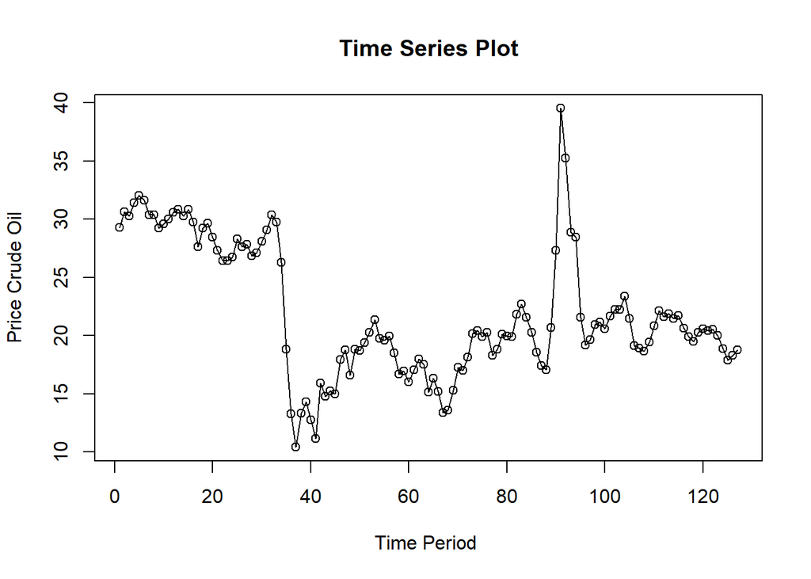

```r
ts.plot(dataco.ts, xlab="Time Period ", ylab="Price Crude Oil",
        main = "Time Series Plot")
points(dataco.ts)
```

```r
#menyimpan plot
dev.copy(png, "plot_dataco.png")
```

```r
dev.off()
```

## Single Exponential Smoothing & Double Exponential Smoothing

Metode Exponential Smoothing merupakan metode pemulusan deret waktu dengan memberikan bobot yang menurun secara eksponensial pada data historis, di mana nilai terbaru mendapat bobot lebih besar dibanding nilai yang lebih lama. Metode ini menggunakan satu atau lebih parameter pemulusan yang secara langsung menentukan besar kecilnya bobot setiap pengamatan. Pemilihan parameter yang tepat akan sangat berpengaruh terhadap hasil ramalan. Secara umum, Exponential Smoothing dibedakan menjadi dua jenis, yaitu model tunggal (single) yang digunakan untuk data tanpa tren maupun musiman, serta model ganda (double) yang mampu menangkap adanya tren pada data.

### Pembagian Data

Pembagian data latih dan data uji dilakukan dengan perbandingan 80% data latih dan 20% data uji.

```r
# jumlah baris data
n <- nrow(dataco)

# hitung batas 80%
n_train <- floor(0.8 * n)

# bagi data
training <- dataco[1:n_train, ]
testing  <- dataco[(n_train+1):n, ]

# ubah ke time series
train.ts <- ts(training$Price)
test.ts  <- ts(testing$Price)
```

### Eksplorasi

Eksplorasi dilakukan dengan membuat plot data deret waktu untuk keseluruhan data, data latih, dan data uji.

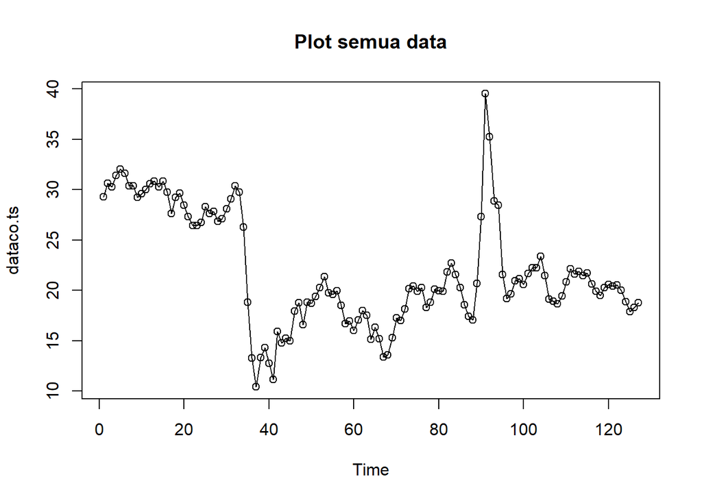

```r
#eksplorasi data
plot(dataco.ts, col="black",main="Plot semua data")
points(dataco.ts)
```

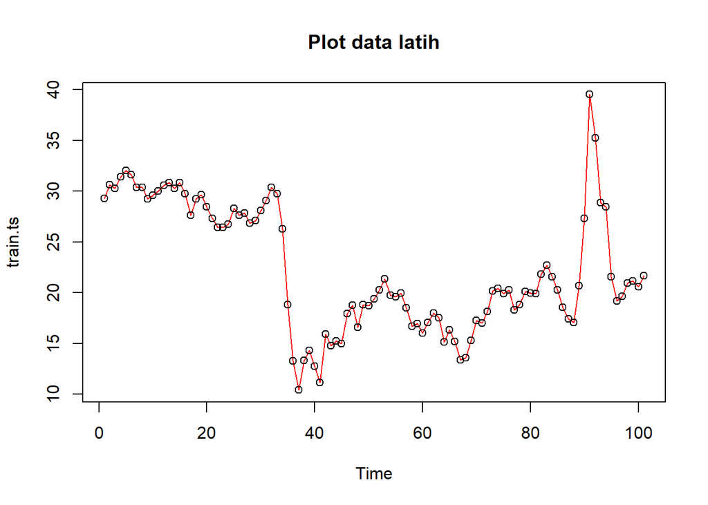

```r
plot(train.ts, col="red",main="Plot data latih")
points(train.ts)
```

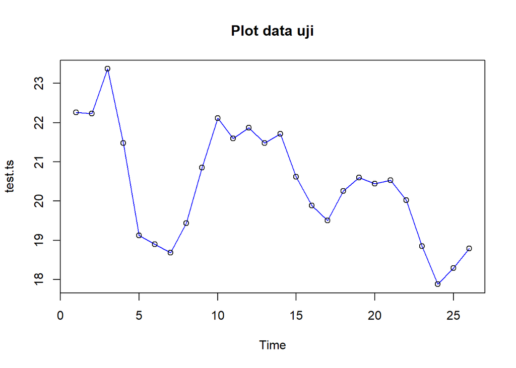

```r
plot(test.ts, col="blue",main="Plot data uji")
points(test.ts)
```

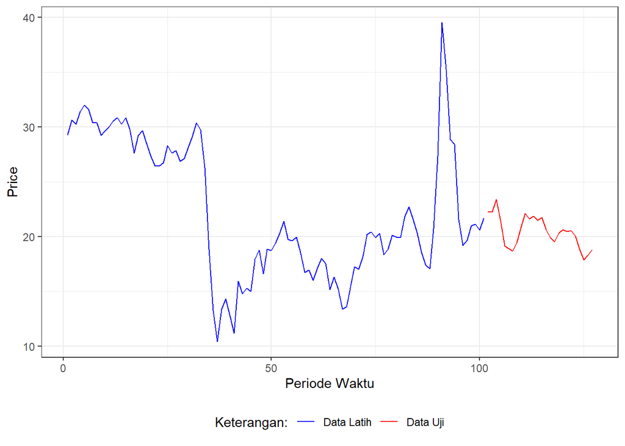

```r
#Eksplorasi dengan GGPLOT
library(ggplot2)
ggplot() +
  geom_line(data = training, aes(x = Period, y = Price, col = "Data Latih")) +
  geom_line(data = testing, aes(x = Period, y = Price, col = "Data Uji")) +
  labs(x = "Periode Waktu", y = "Price", color = "Legend") +
  scale_colour_manual(name="Keterangan:", breaks = c("Data Latih", "Data Uji"),
                      values = c("blue", "red")) +
  theme_bw() + theme(legend.position = "bottom",
                     plot.caption = element_text(hjust=0.5, size=12))
```

## Single Exponential Smoothing

Single Exponential Smoothing (SES) adalah metode peramalan deret waktu yang dikembangkan untuk mengatasi kelemahan Moving Average. Jika pada Moving Average setiap data periode sebelumnya dianggap memiliki bobot yang sama, maka SES memberikan bobot yang semakin mengecil secara eksponensial terhadap data lama, sehingga data terbaru diberi bobot lebih besar.

Single Exponential Smoothing merupakan metode pemulusan yang tepat digunakan untuk data dengan pola stasioner atau konstan.

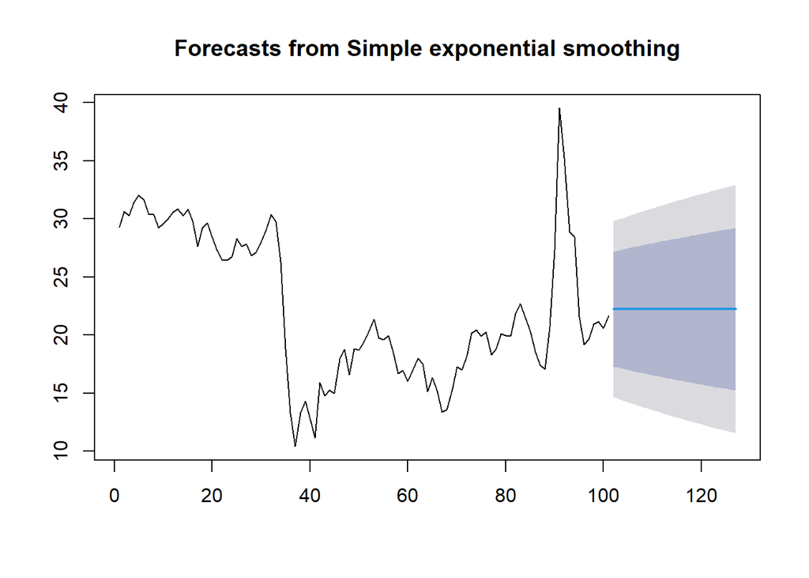

```r
#Cara 1 (fungsi ses)
ses.1 <- ses(train.ts, h = 26, alpha = 0.2)
plot(ses.1)
```

```r
ses.1
```

```
##     Point Forecast    Lo 80    Hi 80    Lo 95    Hi 95
## 102       22.22781 17.28862 27.16699 14.67398 29.78163
## 103       22.22781 17.19081 27.26480 14.52438 29.93123
## 104       22.22781 17.09486 27.36075 14.37764 30.07797
## 105       22.22781 17.00067 27.45495 14.23359 30.22203
## 106       22.22781 16.90814 27.54747 14.09208 30.36353
## 107       22.22781 16.81720 27.63841 13.95300 30.50261
## 108       22.22781 16.72776 27.72785 13.81622 30.63939
## 109       22.22781 16.63976 27.81585 13.68162 30.77399
## 110       22.22781 16.55312 27.90249 13.54912 30.90649
## 111       22.22781 16.46778 27.98783 13.41860 31.03701
## 112       22.22781 16.38369 28.07193 13.29000 31.16562
## 113       22.22781 16.30079 28.15482 13.16321 31.29240
## 114       22.22781 16.21903 28.23658 13.03818 31.41743
## 115       22.22781 16.13837 28.31724 12.91482 31.54079
## 116       22.22781 16.05877 28.39684 12.79308 31.66253
## 117       22.22781 15.98018 28.47543 12.67288 31.78273
## 118       22.22781 15.90257 28.55305 12.55419 31.90143
## 119       22.22781 15.82589 28.62972 12.43693 32.01869
## 120       22.22781 15.75013 28.70548 12.32105 32.13456
## 121       22.22781 15.67524 28.78037 12.20652 32.24909
## 122       22.22781 15.60120 28.85441 12.09328 32.36233
## 123       22.22781 15.52797 28.92764 11.98129 32.47432
## 124       22.22781 15.45554 29.00007 11.87052 32.58509
## 125       22.22781 15.38387 29.07174 11.76091 32.69470
## 126       22.22781 15.31295 29.14266 11.65245 32.80316
## 127       22.22781 15.24275 29.21286 11.54508 32.91053
```

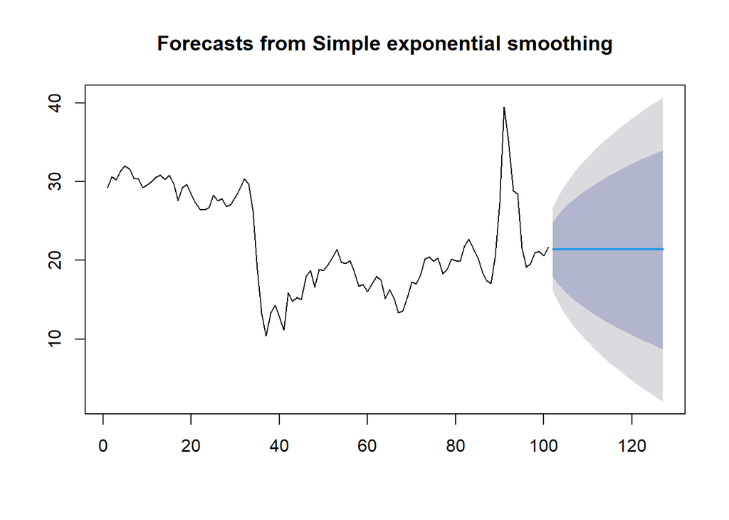

```r
ses.2<- ses(train.ts, h = 26, alpha = 0.7)
plot(ses.2)
```

```r
ses.2
```

```
##     Point Forecast     Lo 80    Hi 80     Lo 95    Hi 95
## 102       21.38219 17.908160 24.85622 16.069119 26.69526
## 103       21.38219 17.141596 25.62279 14.896761 27.86762
## 104       21.38219 16.493796 26.27059 13.906036 28.85835
## 105       21.38219 15.922323 26.84206 13.032043 29.73234
## 106       21.38219 15.405242 27.35914 12.241237 30.52315
## 107       21.38219 14.929465 27.83492 11.513598 31.25078
## 108       21.38219 14.486437 28.27795 10.836045 31.92834
## 109       21.38219 14.070202 28.69418 10.199469 32.56491
## 110       21.38219 13.676418 29.08796  9.597228 33.16715
## 111       21.38219 13.301801 29.46258  9.024302 33.74008
## 112       21.38219 12.943799 29.82058  8.476785 34.28760
## 113       21.38219 12.600380 30.16400  7.951570 34.81281
## 114       21.38219 12.269894 30.49449  7.446135 35.31825
## 115       21.38219 11.950981 30.81340  6.958400 35.80598
## 116       21.38219 11.642505 31.12188  6.486627 36.27775
## 117       21.38219 11.343504 31.42088  6.029344 36.73504
## 118       21.38219 11.053155 31.71123  5.585293 37.17909
## 119       21.38219 10.770747 31.99364  5.153388 37.61099
## 120       21.38219 10.495663 32.26872  4.732682 38.03170
## 121       21.38219 10.227360 32.53702  4.322349 38.44203
## 122       21.38219  9.965361 32.79902  3.921656 38.84273
## 123       21.38219  9.709241 33.05514  3.529954 39.23443
## 124       21.38219  9.458621 33.30576  3.146664 39.61772
## 125       21.38219  9.213161 33.55122  2.771266 39.99312
## 126       21.38219  8.972556 33.79183  2.403292 40.36109
## 127       21.38219  8.736528 34.02785  2.042318 40.72206
```

Pada fungsi `ses()` , terdapat beberapa argumen yang umum digunakan, yaitu

- `y` : nilai data deret waktu
- `alpha` : parameter pemulusan utama (0–1), mengatur bobot data terbaru vs data lama.
- `beta` : parameter pemulusan tren.
- `gamma` : parameter pemulusan musiman.
- `h` : jumlah periode ke depan yang ingin diramalkan (forecast horizon).

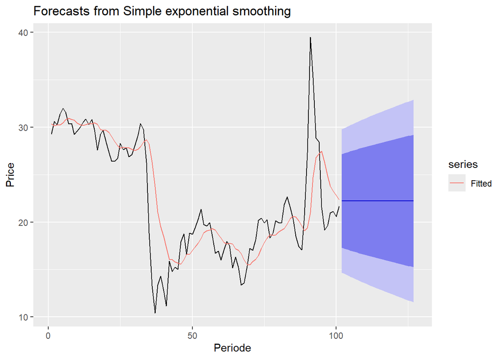

```r
autoplot(ses.1) +
  autolayer(fitted(ses.1), series="Fitted") +
  ylab("Price") + xlab("Periode")
```

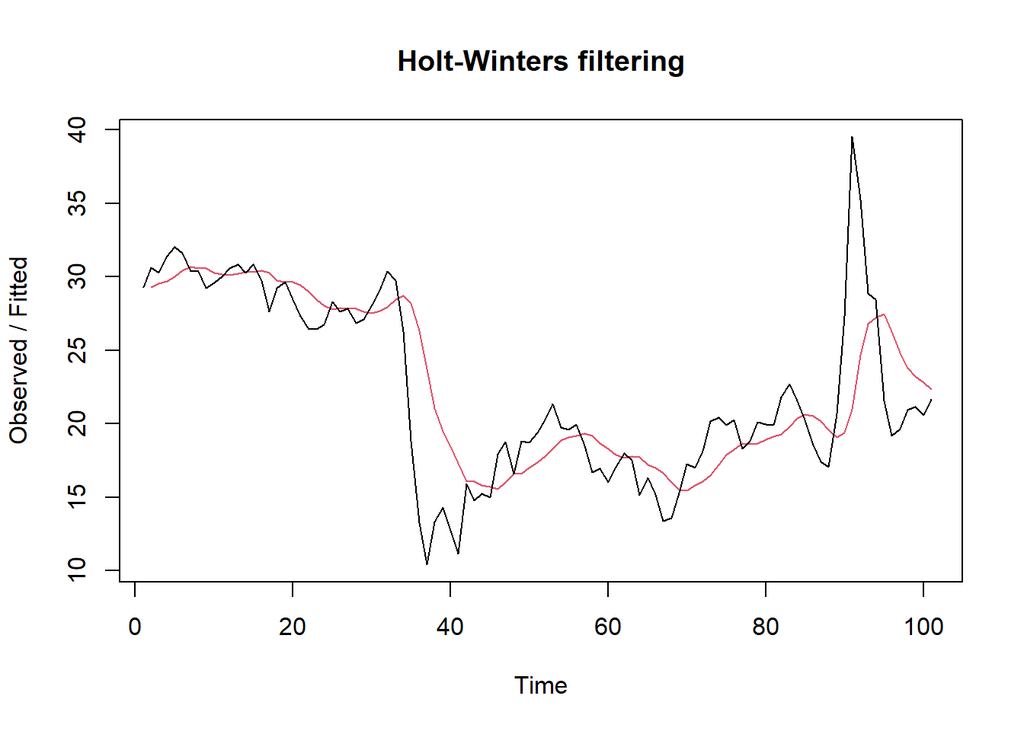

```r
#Cara 2 (fungsi Holtwinter)
ses1<- HoltWinters(train.ts, gamma = FALSE, beta = FALSE, alpha = 0.2)
plot(ses1)
```

```r
#ramalan
ramalan1<- forecast(ses1, h=26)
ramalan1
```

```
##     Point Forecast    Lo 80    Hi 80    Lo 95    Hi 95
## 102       22.22781 17.30390 27.15171 14.69735 29.75826
## 103       22.22781 17.20639 27.24922 14.54822 29.90740
## 104       22.22781 17.11074 27.34487 14.40192 30.05369
## 105       22.22781 17.01684 27.43877 14.25832 30.19729
## 106       22.22781 16.92460 27.53101 14.11725 30.33836
## 107       22.22781 16.83394 27.62167 13.97860 30.47701
## 108       22.22781 16.74478 27.71083 13.84224 30.61337
## 109       22.22781 16.65705 27.79856 13.70807 30.74755
## 110       22.22781 16.57067 27.88494 13.57597 30.87964
## 111       22.22781 16.48560 27.97001 13.44586 31.00975
## 112       22.22781 16.40177 28.05384 13.31765 31.13796
## 113       22.22781 16.31912 28.13649 13.19126 31.26435
## 114       22.22781 16.23762 28.21799 13.06661 31.38900
## 115       22.22781 16.15721 28.29840 12.94363 31.51198
## 116       22.22781 16.07785 28.37776 12.82227 31.63334
## 117       22.22781 15.99951 28.45610 12.70245 31.75316
## 118       22.22781 15.92214 28.53348 12.58411 31.87150
## 119       22.22781 15.84570 28.60991 12.46722 31.98839
## 120       22.22781 15.77017 28.68544 12.35170 32.10391
## 121       22.22781 15.69551 28.76010 12.23753 32.21809
## 122       22.22781 15.62170 28.83391 12.12464 32.33097
## 123       22.22781 15.54870 28.90691 12.01300 32.44261
## 124       22.22781 15.47649 28.97912 11.90256 32.55305
## 125       22.22781 15.40505 29.05056 11.79330 32.66231
## 126       22.22781 15.33434 29.12127 11.68517 32.77045
## 127       22.22781 15.26436 29.19125 11.57813 32.87748
```

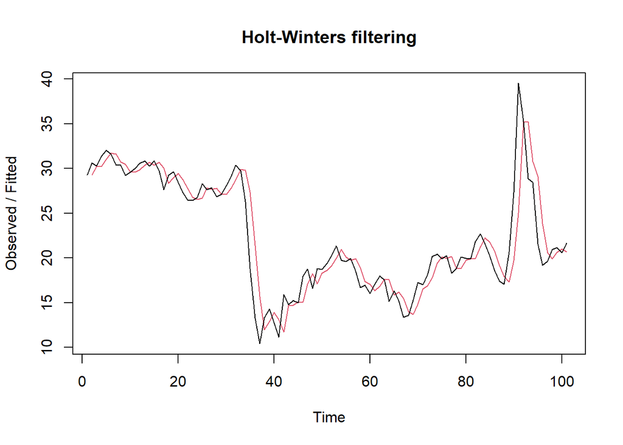

```r
ses2<- HoltWinters(train.ts, gamma = FALSE, beta = FALSE, alpha = 0.7)
plot(ses2)
```

```r
#ramalan
ramalan2<- forecast(ses2, h=26)
ramalan2
```

```
##     Point Forecast     Lo 80    Hi 80     Lo 95    Hi 95
## 102       21.38219 17.910757 24.85362 16.073092 26.69129
## 103       21.38219 17.144766 25.61962 14.901609 27.86277
## 104       21.38219 16.497451 26.26693 13.911626 28.85276
## 105       21.38219 15.926405 26.83798 13.038286 29.72610
## 106       21.38219 15.409711 27.35467 12.248071 30.51631
## 107       21.38219 14.934289 27.83009 11.520976 31.24341
## 108       21.38219 14.491592 28.27279 10.843929 31.92045
## 109       21.38219 14.075669 28.68871 10.207829 32.55655
## 110       21.38219 13.682179 29.08220  9.606039 33.15834
## 111       21.38219 13.307842 29.45654  9.033541 33.73084
## 112       21.38219 12.950108 29.81427  8.486433 34.27795
## 113       21.38219 12.606945 30.15744  7.961611 34.80277
## 114       21.38219 12.276706 30.48768  7.456554 35.30783
## 115       21.38219 11.958032 30.80635  6.969184 35.79520
## 116       21.38219 11.649787 31.11460  6.497763 36.26662
## 117       21.38219 11.351009 31.41337  6.040822 36.72356
## 118       21.38219 11.060877 31.70351  5.597103 37.16728
## 119       21.38219 10.778680 31.98570  5.165521 37.59886
## 120       21.38219 10.503802 32.26058  4.745130 38.01925
## 121       21.38219 10.235699 32.52868  4.335103 38.42928
## 122       21.38219  9.973896 32.79049  3.934710 38.82967
## 123       21.38219  9.717968 33.04641  3.543301 39.22108
## 124       21.38219  9.467535 33.29685  3.160297 39.60408
## 125       21.38219  9.222259 33.54212  2.785180 39.97920
## 126       21.38219  8.981834 33.78255  2.417481 40.34690
## 127       21.38219  8.745982 34.01840  2.056777 40.70760
```

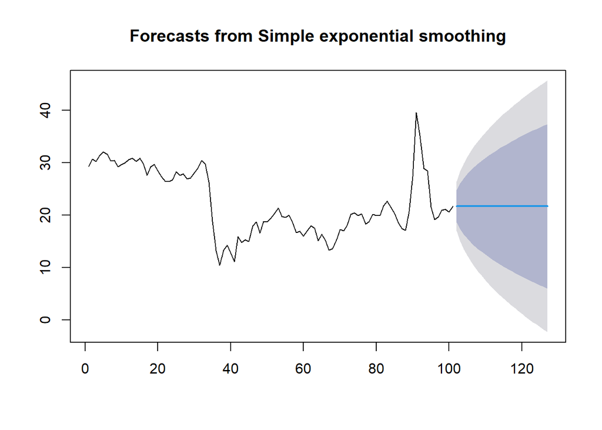

```r
#SES
ses.opt <- ses(train.ts, h = 26, alpha = NULL)
plot(ses.opt)
```

```r
ses.opt
```

```
##     Point Forecast     Lo 80    Hi 80      Lo 95    Hi 95
## 102       21.67989 18.605512 24.75426 16.9780358 26.38174
## 103       21.67989 17.332281 26.02749 15.0307975 28.32898
## 104       21.67989 16.355268 27.00451 13.5365843 29.82319
## 105       21.67989 15.531598 27.82818 12.2768893 31.08289
## 106       21.67989 14.805925 28.55385 11.1670684 32.19271
## 107       21.67989 14.149864 29.20991 10.1637096 33.19607
## 108       21.67989 13.546552 29.81322  9.2410233 34.11875
## 109       21.67989 12.985001 30.37477  8.3822060 34.97757
## 110       21.67989 12.457581 30.90220  7.5755859 35.78419
## 111       21.67989 11.958733 31.40104  6.8126648 36.54711
## 112       21.67989 11.484264 31.87551  6.0870269 37.27275
## 113       21.67989 11.030914 32.32886  5.3936881 37.96609
## 114       21.67989 10.596092 32.76368  4.7286846 38.63109
## 115       21.67989 10.177695 33.18208  4.0888025 39.27097
## 116       21.67989  9.773993 33.58578  3.4713933 39.88838
## 117       21.67989  9.383538 33.97624  2.8742434 40.48553
## 118       21.67989  9.005105 34.35467  2.2954804 41.06430
## 119       21.67989  8.637648 34.72213  1.7335037 41.62627
## 120       21.67989  8.280264 35.07951  1.1869322 42.17284
## 121       21.67989  7.932168 35.42761  0.6545645 42.70521
## 122       21.67989  7.592670 35.76711  0.1353476 43.22443
## 123       21.67989  7.261164 36.09861 -0.3716473 43.73142
## 124       21.67989  6.937110 36.42267 -0.8672448 44.22702
## 125       21.67989  6.620028 36.73975 -1.3521807 44.71196
## 126       21.67989  6.309485 37.05029 -1.8271148 45.18689
## 127       21.67989  6.005093 37.35468 -2.2926415 45.65242
```

```r
#Lamda Optimum Holt Winter
HWopt<- HoltWinters(train.ts, gamma = FALSE, beta = FALSE,alpha = NULL)
HWopt
```

```
## Holt-Winters exponential smoothing without trend and without seasonal component.
##
## Call:
## HoltWinters(x = train.ts, alpha = NULL, beta = FALSE, gamma = FALSE)
##
## Smoothing parameters:
##  alpha: 0.9999339
##  beta : FALSE
##  gamma: FALSE
##
## Coefficients:
##       [,1]
## a 21.67993
```

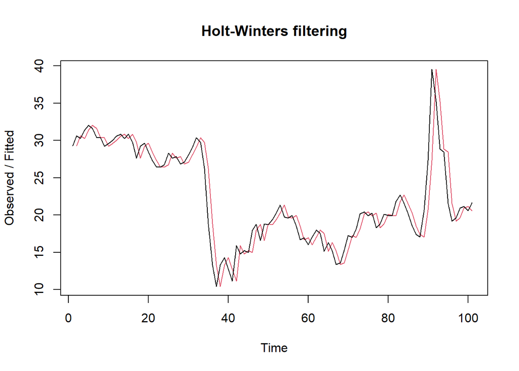

```r
plot(HWopt)
```

```r
#ramalan
ramalanopt<- forecast(HWopt, h=26)
ramalanopt
```

```
##     Point Forecast     Lo 80    Hi 80      Lo 95    Hi 95
## 102       21.67993 18.607137 24.75272 16.9805004 26.37935
## 103       21.67993 17.334489 26.02536 15.0341542 28.32570
## 104       21.67993 16.357933 27.00192 13.5406408 29.81921
## 105       21.67993 15.534652 27.82520 12.2815407 31.07831
## 106       21.67993 14.809324 28.55053 11.1722466 32.18761
## 107       21.67993 14.153575 29.20628 10.1693653 33.19049
## 108       21.67993 13.550550 29.80930  9.2471190 34.11273
## 109       21.67993 12.989268 30.37058  8.3887120 34.97114
## 110       21.67993 12.462100 30.89775  7.5824776 35.77737
## 111       21.67993 11.963491 31.39636  6.8199215 36.53993
## 112       21.67993 11.489249 31.87060  6.0946312 37.26522
## 113       21.67993 11.036117 32.32374  5.4016246 37.95823
## 114       21.67993 10.601503 32.75835  4.7369399 38.62291
## 115       21.67993 10.183307 33.17654  4.0973648 39.26249
## 116       21.67993  9.779799 33.58005  3.4802518 39.87960
## 117       21.67993  9.389531 33.97032  2.8833885 40.47646
## 118       21.67993  9.011280 34.34857  2.3049034 41.05495
## 119       21.67993  8.643999 34.71585  1.7431965 41.61666
## 120       21.67993  8.286787 35.07306  1.1968875 42.16296
## 121       21.67993  7.938858 35.42099  0.6647756 42.69508
## 122       21.67993  7.599523 35.76033  0.1458082 43.21404
## 123       21.67993  7.268176 36.09168 -0.3609431 43.72079
## 124       21.67993  6.944278 36.41557 -0.8563024 44.21615
## 125       21.67993  6.627348 36.73250 -1.3410052 44.70086
## 126       21.67993  6.316955 37.04290 -1.8157109 45.17556
## 127       21.67993  6.012710 37.34714 -2.2810138 45.64087
```

#### Akurasi Data Latih

```r
#Keakuratan Metode
#Pada data training

# SES dengan alpha = 0.2
SSE1<-ses1$SSE
MSE1<-ses1$SSE/length(train.ts)
RMSE1<-sqrt(MSE1)

akurasi1 <- matrix(c(SSE1,MSE1,RMSE1))
row.names(akurasi1)<- c("SSE", "MSE", "RMSE")
colnames(akurasi1) <- c("Akurasi lamda=0.2")
akurasi1
```

```
##      Akurasi lamda=0.2
## SSE        1473.840558
## MSE          14.592481
## RMSE          3.820011
```

```r
# SES dengan alpha = 0.7
SSE2<-ses2$SSE
MSE2<-ses2$SSE/length(train.ts)
RMSE2<-sqrt(MSE2)

akurasi2 <- matrix(c(SSE2,MSE2,RMSE2))
row.names(akurasi2)<- c("SSE", "MSE", "RMSE")
colnames(akurasi2) <- c("Akurasi lamda=0.7")
akurasi2
```

```
##      Akurasi lamda=0.7
## SSE         727.677956
## MSE           7.204732
## RMSE          2.684163
```

```r
#Cara Manual
# Alpha = 0.2
fitted1<-ramalan1$fitted
sisaan1<-ramalan1$residuals
head(sisaan1)
```

```
## Time Series:
## Start = 1
## End = 6
## Frequency = 1
## [1]       NA 1.360000 0.708000 1.696400 1.977120 1.171696
```

```r
resid1<-training$Price-ramalan1$fitted
head(resid1)
```

```
## Time Series:
## Start = 1
## End = 6
## Frequency = 1
## [1]       NA 1.360000 0.708000 1.696400 1.977120 1.171696
```

```r
SSE.1=sum(sisaan1[2:length(train.ts)]^2)
SSE.1
```

```
## [1] 1473.841
```

```r
MSE.1 = SSE.1/length(train.ts)
MSE.1
```

```
## [1] 14.59248
```

```r
MAPE.1 = sum(abs(sisaan1[2:length(train.ts)]/train.ts[2:length(train.ts)])*
               100)/length(train.ts)
MAPE.1
```

```
## [1] 12.52704
```

```r
akurasi.1 <- matrix(c(SSE.1,MSE.1,MAPE.1))
row.names(akurasi.1)<- c("SSE", "MSE", "MAPE")
colnames(akurasi.1) <- c("Akurasi lamda=0.2")
akurasi.1
```

```
##      Akurasi lamda=0.2
## SSE         1473.84056
## MSE           14.59248
## MAPE          12.52704
```

```r
# Alpha = 0.7
fitted2<-ramalan2$fitted
sisaan2<-ramalan2$residuals
head(sisaan2)
```

```
## Time Series:
## Start = 1
## End = 6
## Frequency = 1
## [1]        NA  1.360000  0.028000  1.138400  0.961520 -0.121544
```

```r
resid2<-training$Price-ramalan2$fitted
head(resid2)
```

```
## Time Series:
## Start = 1
## End = 6
## Frequency = 1
## [1]        NA  1.360000  0.028000  1.138400  0.961520 -0.121544
```

```r
SSE.2=sum(sisaan2[2:length(train.ts)]^2)
SSE.2
```

```
## [1] 727.678
```

```r
MSE.2 = SSE.2/length(train.ts)
MSE.2
```

```
## [1] 7.204732
```

```r
MAPE.2 = sum(abs(sisaan2[2:length(train.ts)]/train.ts[2:length(train.ts)])*
               100)/length(train.ts)
MAPE.2
```

```
## [1] 7.986187
```

```r
akurasi.2 <- matrix(c(SSE.2,MSE.2,MAPE.2))
row.names(akurasi.2)<- c("SSE", "MSE", "MAPE")
colnames(akurasi.2) <- c("Akurasi lamda=0.7")
akurasi.2
```

```
##      Akurasi lamda=0.7
## SSE         727.677956
## MSE           7.204732
## MAPE          7.986187
```

#### Akurasi Data Uji

```r
# jumlah observasi uji
n_test <- nrow(testing)

# error (ramalan - aktual), samakan panjang dan tipe numeric
e1   <- as.numeric(ramalan1$mean)[1:n_test] - as.numeric(testing$Price)
e2   <- as.numeric(ramalan2$mean)[1:n_test] - as.numeric(testing$Price)
eopt <- as.numeric(ramalanopt$mean)[1:n_test] - as.numeric(testing$Price)

# SSE / MSE / RMSE untuk masing-masing model (abaikan NA)
SSEtesting1  <- sum(e1^2,  na.rm = TRUE)
MSEtesting1  <- mean(e1^2, na.rm = TRUE)
RMSEtesting1 <- sqrt(MSEtesting1)

SSEtesting2  <- sum(e2^2,  na.rm = TRUE)
MSEtesting2  <- mean(e2^2, na.rm = TRUE)
RMSEtesting2 <- sqrt(MSEtesting2)

SSEtestingopt  <- sum(eopt^2,  na.rm = TRUE)
MSEtestingopt  <- mean(eopt^2, na.rm = TRUE)
RMSEtestingopt <- sqrt(MSEtestingopt)

# Tabel ringkas
akurasitesting_SSE <- matrix(c(SSEtesting1, SSEtesting2, SSEtestingopt),
                             nrow = 3,
                             dimnames = list(c("SSE1","SSE2","SSEopt"), "Nilai"))
akurasitesting_MSE <- matrix(c(MSEtesting1, MSEtesting2, MSEtestingopt),
                             nrow = 3,
                             dimnames = list(c("MSE1","MSE2","MSEopt"), "Nilai"))
akurasitesting_RMSE <- matrix(c(RMSEtesting1, RMSEtesting2, RMSEtestingopt),
                              nrow = 3,
                              dimnames = list(c("RMSE1","RMSE2","RMSEopt"), "Nilai"))

akurasitesting_SSE
```

```
##            Nilai
## SSE1   136.82243
## SSE2    75.66766
## SSEopt  92.95863
```

```r
akurasitesting_MSE
```

```
##           Nilai
## MSE1   5.262401
## MSE2   2.910295
## MSEopt 3.575332
```

```r
akurasitesting_RMSE
```

```
##            Nilai
## RMSE1   2.293992
## RMSE2   1.705959
## RMSEopt 1.890855
```

## *Double Exponential Smoothing* (DES)

Metode pemulusan *Double Exponential Smoothing* (DES) digunakan untuk data yang memiliki pola tren. Metode DES adalah metode semacam SES, hanya saja dilakukan dua kali, yaitu pertama untuk tahapan ‘level’ dan kedua untuk tahapan ‘tren’. Pemulusan menggunakan metode ini akan menghasilkan peramalan tidak konstan untuk periode berikutnya.

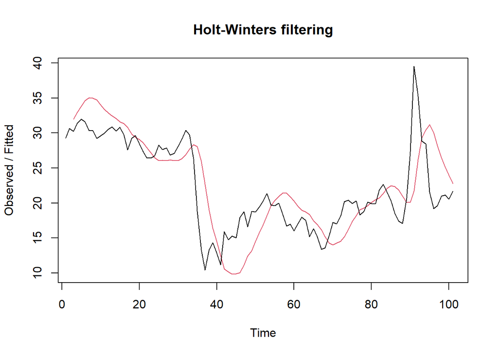

```r
#Lamda=0.2 dan gamma=0.2
des.1<- HoltWinters(train.ts, gamma = FALSE, beta = 0.2, alpha = 0.2)
plot(des.1)
```

```r
#ramalan
ramalandes1<- forecast(des.1, h=26)
ramalandes1
```

```
##     Point Forecast        Lo 80    Hi 80       Lo 95    Hi 95
## 102      22.000843  16.23259691 27.76909  13.1790717 30.82262
## 103      21.439123  15.50707690 27.37117  12.3668413 30.51141
## 104      20.877403  14.72941549 27.02539  11.4748675 30.27994
## 105      20.315683  13.89658071 26.73478  10.4985133 30.13285
## 106      19.753963  13.00733311 26.50059   9.4358832 30.07204
## 107      19.192242  12.06198039 26.32250   8.2874477 30.09704
## 108      18.630522  11.06202005 26.19902   7.0554971 30.20555
## 109      18.068802  10.00975445 26.12785   5.7435524 30.39405
## 110      17.507082   8.90794366 26.10622   4.3558349 30.65833
## 111      16.945362   7.75953091 26.13119   2.8968459 30.99388
## 112      16.383641   6.56744836 26.19983   1.3710697 31.39621
## 113      15.821921   5.33449394 26.30935  -0.2172147 31.86106
## 114      15.260201   4.06326338 26.45714  -1.8640373 32.38444
## 115      14.698481   2.75612077 26.64084  -3.5657827 32.96274
## 116      14.136761   1.41519404 26.85833  -5.3191965 33.59272
## 117      13.575040   0.04238496 27.10770  -7.1213700 34.27145
## 118      13.013320  -1.36061306 27.38725  -8.9697137 34.99635
## 119      12.451600  -2.79229423 27.69549 -10.8619243 35.76512
## 120      11.889880  -4.25131895 28.03108 -12.7959534 36.57571
## 121      11.328159  -5.73649357 28.39281 -14.7699752 37.42629
## 122      10.766439  -7.24675175 28.77963 -16.7823591 38.31524
## 123      10.204719  -8.78113797 29.19058 -18.8316436 39.24108
## 124       9.642999 -10.33879301 29.62479 -20.9165147 40.20251
## 125       9.081279 -11.91894135 30.08150 -23.0357863 41.19834
## 126       8.519558 -13.52088032 30.56000 -25.1883838 42.22750
## 127       7.957838 -15.14397082 31.05965 -27.3733298 43.28901
```

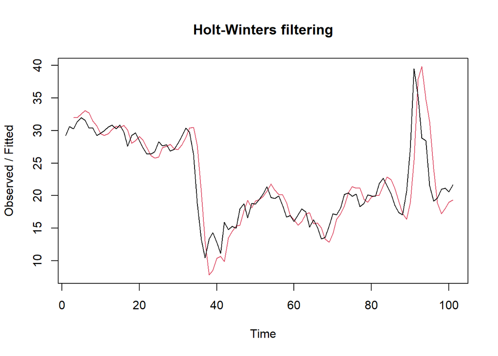

```r
#Lamda=0.6 dan gamma=0.3
des.2<- HoltWinters(train.ts, gamma = FALSE, beta = 0.3, alpha = 0.6)
plot(des.2)
```

```r
#ramalan
ramalandes2<- forecast(des.2, h=26)
ramalandes2
```

```
##     Point Forecast       Lo 80    Hi 80      Lo 95     Hi 95
## 102       20.55837  16.4342615 24.68247  14.251092  26.86564
## 103       20.37659  15.1462885 25.60689  12.377534  28.37565
## 104       20.19481  13.6350234 26.75461  10.162480  30.22715
## 105       20.01304  11.9424266 28.08365   7.670103  32.35597
## 106       19.83126  10.0962769 29.56625   4.942887  34.71964
## 107       19.64949   8.1152549 31.18372   2.009402  37.28957
## 108       19.46771   6.0125043 32.92292  -1.110251  40.04567
## 109       19.28593   3.7977357 34.77413  -4.401221  42.97309
## 110       19.10416   1.4784437 36.72987  -7.852045  46.06036
## 111       18.92238  -0.9393713 38.78413 -11.453548  49.29831
## 112       18.74061  -3.4507603 40.93197 -15.198160  52.67937
## 113       18.55883  -6.0515424 43.16920 -19.079486  56.19714
## 114       18.37705  -8.7381160 45.49222 -23.092019  59.84612
## 115       18.19528 -11.5073299 47.89788 -27.230940  63.62149
## 116       18.01350 -14.3563912 50.38339 -31.491977  67.51898
## 117       17.83172 -17.2827978 52.94625 -35.871303  71.53475
## 118       17.64995 -20.2842884 55.58418 -40.365460  75.66536
## 119       17.46817 -23.3588037 58.29515 -44.971299  79.90764
## 120       17.28640 -26.5044560 61.07725 -49.685933  84.25872
## 121       17.10462 -29.7195059 63.92875 -54.506701  88.71594
## 122       16.92284 -33.0023421 66.84803 -59.431139  93.27683
## 123       16.74107 -36.3514662 69.83360 -64.456956  97.93909
## 124       16.55929 -39.7654791 72.88406 -69.582011 102.70059
## 125       16.37752 -43.2430701 75.99810 -74.804301 107.55933
## 126       16.19574 -46.7830078 79.17449 -80.121942 112.51342
## 127       16.01396 -50.3841318 82.41206 -85.533160 117.56109
```

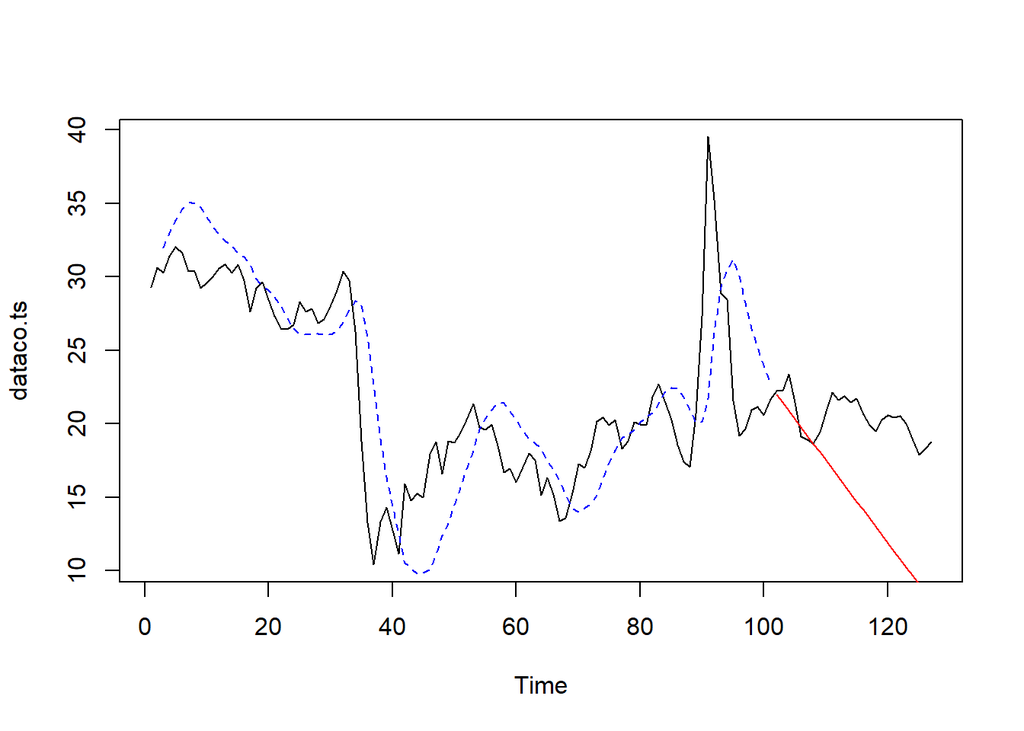

```r
plot(dataco.ts)
lines(des.1$fitted[,1], lty=2, col="blue")
lines(ramalandes1$mean, col="red")
```

```r
#Lamda dan gamma optimum
des.opt<- HoltWinters(train.ts, gamma = FALSE)
des.opt
```

```
## Holt-Winters exponential smoothing with trend and without seasonal component.
##
## Call:
## HoltWinters(x = train.ts, gamma = FALSE)
##
## Smoothing parameters:
##  alpha: 1
##  beta : 0.05619441
##  gamma: FALSE
##
## Coefficients:
##           [,1]
## a 21.680000000
## b -0.001397268
```

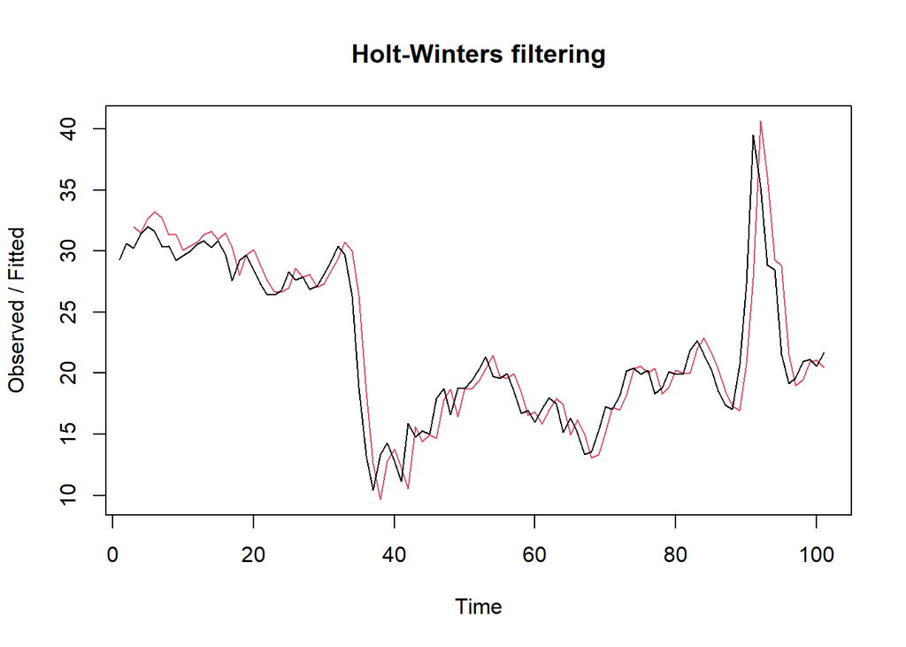

```r
plot(des.opt)
```

```r
#ramalan
ramalandesopt<- forecast(des.opt, h=26)
ramalandesopt
```

```
##     Point Forecast      Lo 80    Hi 80       Lo 95    Hi 95
## 102       21.67860 18.4867367 24.87047  16.7970648 26.56014
## 103       21.67721 17.0346622 26.31975  14.5770482 28.77736
## 104       21.67581 15.8311576 27.52046  12.7371864 30.61443
## 105       21.67441 14.7409737 28.60785  11.0706338 32.27819
## 106       21.67301 13.7134042 29.63262   9.4998415 33.84619
## 107       21.67162 12.7232770 30.61996   7.9863123 35.35692
## 108       21.67022 11.7561341 31.58430   6.5079345 36.83250
## 109       21.66882 10.8028826 32.53476   5.0508017 38.28684
## 110       21.66742  9.8574378 33.47741   3.6056084 39.72924
## 111       21.66603  8.9155419 34.41651   2.1658427 41.16621
## 112       21.66463  7.9741132 35.35515   0.7267914 42.60247
## 113       21.66323  7.0308629 36.29560  -0.7150459 44.04151
## 114       21.66184  6.0840559 37.23962  -2.1623225 45.48599
## 115       21.66044  5.1323561 38.18852  -3.6170821 46.93796
## 116       21.65904  4.1747212 39.14336  -5.0809187 48.39900
## 117       21.65764  3.2103301 40.10496  -6.5550879 49.87038
## 118       21.65625  2.2385312 41.07396  -8.0405863 51.35308
## 119       21.65485  1.2588045 42.05089  -9.5382093 52.84791
## 120       21.65345  0.2707336 43.03617 -11.0485937 54.35550
## 121       21.65205 -0.7260154 44.03012 -12.5722502 55.87636
## 122       21.65066 -1.7317103 45.03303 -14.1095881 57.41090
## 123       21.64926 -2.7465649 46.04509 -15.6609346 58.95945
## 124       21.64786 -3.7707494 47.06648 -17.2265499 60.52228
## 125       21.64647 -4.8043976 48.09733 -18.8066388 62.09957
## 126       21.64507 -5.8476139 49.13775 -20.4013607 63.69150
## 127       21.64367 -6.9004776 50.18782 -22.0108371 65.29818
```

#### Akurasi Data Latih

```r
#Akurasi Data Training
ssedes.train1<-des.1$SSE
msedes.train1<-ssedes.train1/length(train.ts)
sisaandes1<-ramalandes1$residuals
head(sisaandes1)
```

```
## Time Series:
## Start = 1
## End = 6
## Frequency = 1
## [1]        NA        NA -1.740000 -1.552400 -1.850224 -3.044474
```

```r
mapedes.train1 <- sum(abs(sisaandes1[3:length(train.ts)]/train.ts[3:length(train.ts)])
                      *100)/length(train.ts)

akurasides.1 <- matrix(c(ssedes.train1,msedes.train1,mapedes.train1))
row.names(akurasides.1)<- c("SSE", "MSE", "MAPE")
colnames(akurasides.1) <- c("Akurasi lamda=0.2 dan gamma=0.2")
akurasides.1
```

```
##      Akurasi lamda=0.2 dan gamma=0.2
## SSE                       2008.68475
## MSE                         19.88797
## MAPE                        16.64006
```

```r
ssedes.train2<-des.2$SSE
msedes.train2<-ssedes.train2/length(train.ts)
sisaandes2<-ramalandes2$residuals
head(sisaandes2)
```

```
## Time Series:
## Start = 1
## End = 6
## Frequency = 1
## [1]        NA        NA -1.740000 -0.612800 -0.561616 -1.470052
```

```r
mapedes.train2 <- sum(abs(sisaandes2[3:length(train.ts)]/train.ts[3:length(train.ts)])
                      *100)/length(train.ts)

akurasides.2 <- matrix(c(ssedes.train2,msedes.train2,mapedes.train2))
row.names(akurasides.2)<- c("SSE", "MSE", "MAPE")
colnames(akurasides.2) <- c("Akurasi lamda=0.6 dan gamma=0.3")
akurasides.2
```

```
##      Akurasi lamda=0.6 dan gamma=0.3
## SSE                      1015.618017
## MSE                        10.055624
## MAPE                        9.727684
```

```r
# Cek berapa banyak hasil ramalan yang Anda buat
length(ramalandes1$mean)
```

```
## [1] 26
```

```r
# Cek berapa banyak baris data di testing set Anda
nrow(testing)
```

```
## [1] 26
```

#### Akurasi Data Uji

```r
#Akurasi Data Testing
selisihdes1<-ramalandes1$mean-testing$Price
selisihdes1
```

```
## Time Series:
## Start = 102
## End = 127
## Frequency = 1
##  [1]  -0.25915663  -0.79087683  -2.49259703  -1.16431724   0.63396256
##  [6]   0.29224235  -0.04947785  -1.37119806  -3.34291826  -5.16463846
## [11]  -5.21635867  -6.04807887  -6.21979908  -7.01151928  -6.48323948
## [16]  -6.31495969  -6.48667989  -7.80840010  -8.71012030  -9.11184050
## [21]  -9.76356071  -9.81528091  -9.20700112  -8.79872132  -9.77044152
## [26] -10.83216173
```

```r
SSEtestingdes1<-sum(selisihdes1^2)
MSEtestingdes1<-SSEtestingdes1/length(testing$Price)
MAPEtestingdes1<-sum(abs(selisihdes1/testing$Price)*100)/length(testing$Price)

selisihdes2<-ramalandes2$mean-testing$Price
selisihdes2
```

```
## Time Series:
## Start = 102
## End = 127
## Frequency = 1
##  [1] -1.7016333 -1.8534094 -3.1751856 -1.4669618  0.7112621  0.7494859
##  [7]  0.7877098 -0.1540664 -1.7458426 -3.1876187 -2.8593949 -3.3111711
## [13] -3.1029472 -3.5147234 -2.6064995 -2.0582757 -1.8500519 -2.7918280
## [19] -3.3136042 -3.3353803 -3.6071565 -3.2789327 -2.2907088 -1.5024850
## [25] -2.0942612 -2.7760373
```

```r
SSEtestingdes2<-sum(selisihdes2^2)
MSEtestingdes2<-SSEtestingdes2/length(testing$Price)
MAPEtestingdes2<-sum(abs(selisihdes2/testing$Price)*100)/length(testing$Price)

selisihdesopt<-ramalandesopt$mean-testing$Price
selisihdesopt
```

```
## Time Series:
## Start = 102
## End = 127
## Frequency = 1
##  [1] -0.58139727 -0.55279454 -1.69419180  0.19441093  2.55301366  2.77161639
##  [7]  2.99021912  2.22882185  0.81742459 -0.44397268  0.06463005 -0.20676722
## [13]  0.18183551 -0.04956175  1.03904098  1.76764371  2.15624644  1.39484917
## [19]  1.05345190  1.21205464  1.12065737  1.62926010  2.79786283  3.76646556
## [25]  3.35506830  2.85367103
```

```r
SSEtestingdesopt<-sum(selisihdesopt^2)
MSEtestingdesopt<-SSEtestingdesopt/length(testing$Price)
MAPEtestingdesopt<-sum(abs(selisihdesopt/testing$Price)*100)/length(testing$Price)

akurasitestingdes <-
  matrix(c(SSEtestingdes1,MSEtestingdes1,MAPEtestingdes1,SSEtestingdes2,MSEtestingdes2,
           MAPEtestingdes2,SSEtestingdesopt,MSEtestingdesopt,MAPEtestingdesopt),
         nrow=3,ncol=3)
row.names(akurasitestingdes)<- c("SSE", "MSE", "MAPE")
colnames(akurasitestingdes) <- c("des ske1","des ske2","des opt")
akurasitestingdes
```

```
##        des ske1   des ske2   des opt
## SSE  1110.61837 162.318911 91.310817
## MSE    42.71609   6.243035  3.511955
## MAPE   27.42313  11.164788  7.805342
```

#### Perbandingan SES dan DES

```r
MSEfull <-
  matrix(c(MSEtesting1,MSEtesting2,MSEtestingopt,MSEtestingdes1,MSEtestingdes2,
           MSEtestingdesopt),nrow=3,ncol=2)
row.names(MSEfull)<- c("ske 1", "ske 2", "ske opt")
colnames(MSEfull) <- c("ses","des")
MSEfull
```

```
##              ses       des
## ske 1   5.262401 42.716091
## ske 2   2.910295  6.243035
## ske opt 3.575332  3.511955
```

## Kesimpulan

Dalam skenario optimum, metode DES lebih unggul dibandingkan metode SES dengan selisih 0.06. Hal ini bisa disebabkan oleh kemampuan metode DES dalam menangkap tren lokal karena dalam metode DES terdapat 2 parameter (alpha dan beta) yang dapat menyesuaikan metode DES dengan lonjakan dan perununan dalam dataset Crude Oil Price.